# lawCrimePlots.Rmd

Will W

11/8/2017

### Data Preparation

> See “lawStaff_vs_Crime_Plot” R script

### Mapping the Data

> See “lawStaff_vs_Crime_Plot” R script

### Looking at Number of Sworn Officers by County

> Pretty interesting to see there are many counties which have no police department, our policing data does not reflect how resources are spread out for each one amongst neighboring counties. Generally, there is one police department per county with 1 exception. In the middle of the state, we see that the cluster of departments are responsible for patrolling the entire North to South region of the state.

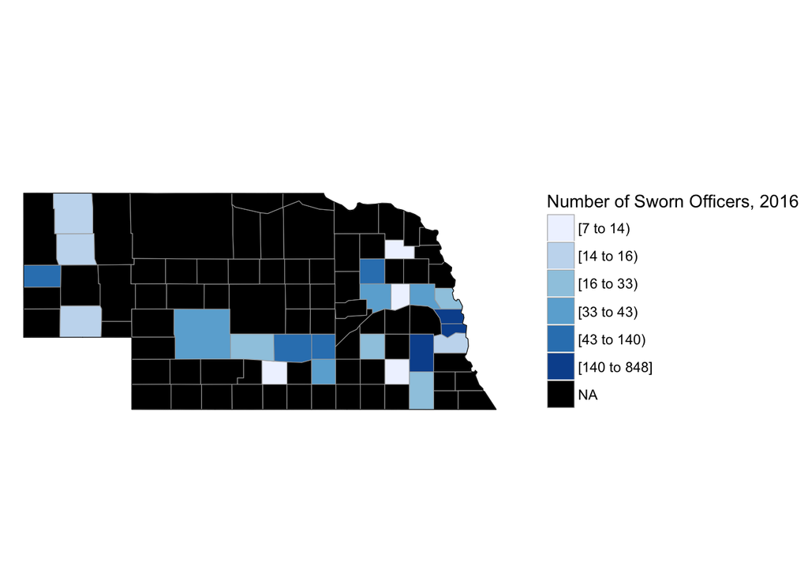

### Population covered by County

> While we mapped by county, each county represents a department. Here we can see the general population densities of Nebraska, as well as the additional burden placed on those central agencies - as they have a relatively high amount of population to cover given the size of the geographic area they operate in.

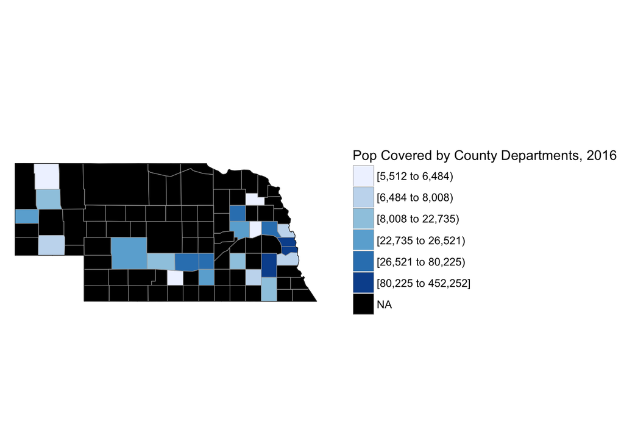

```r
county_mapPop
```

### SO per 1000 People by County

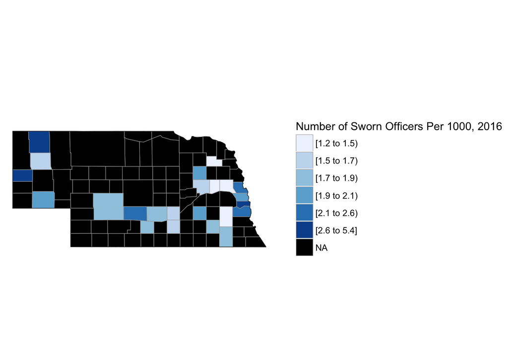

### Annual SO Hiring Trends by Gender

> Hiring trends appear consistent statewide by gender, although only 5-10 female officers are being hired or leaving each year. Due to the relative involatile nature of this visualization, I’m not sure it’s meaningful in our research.

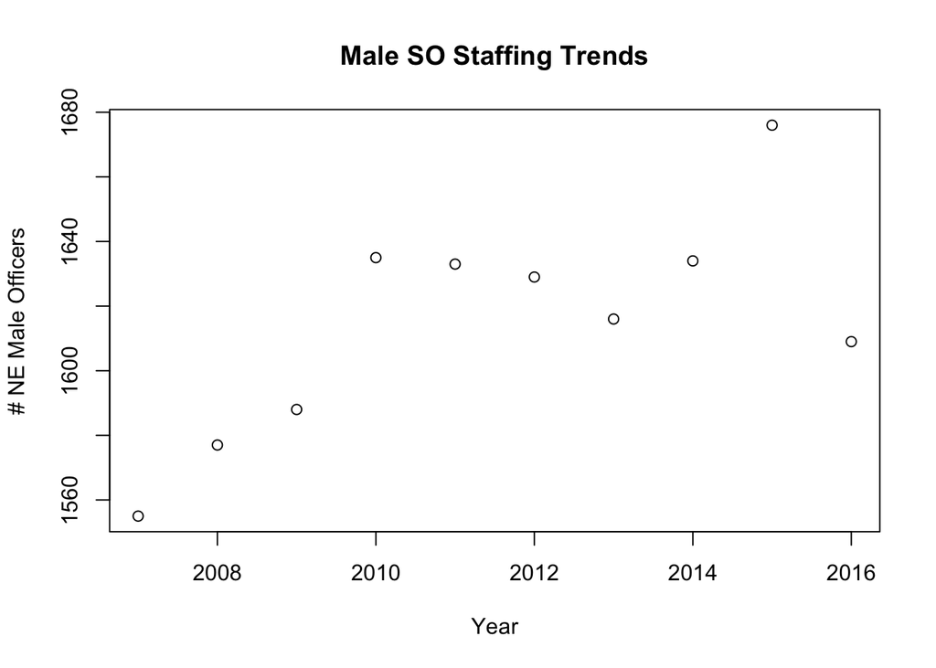

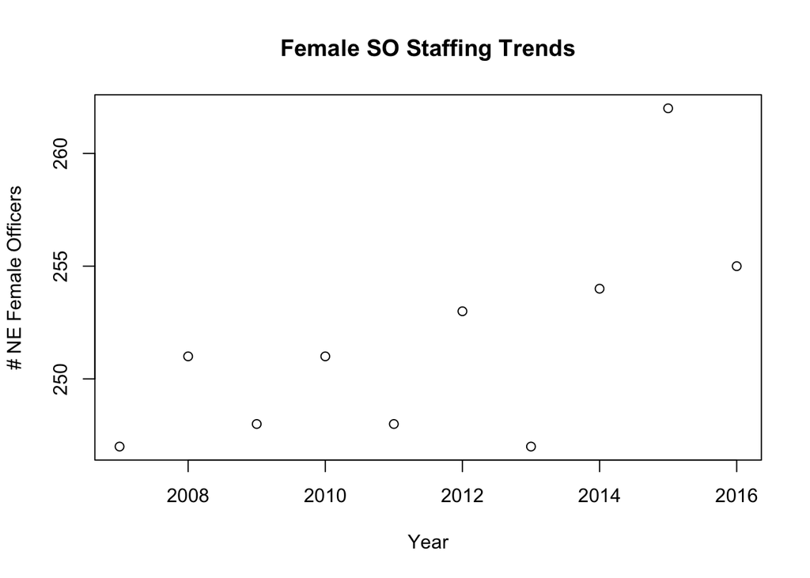